# Regular Expressions

Instructor - Soumya Mukherjee  
Content Credit- Dr. Matthew Beckman and Olivia Beck

July 27, 2023

# Chapter 17: Key Ideas

- Regular expressions allow us to match meaningful **patterns** in character strings
- Some popular uses:
  - detect whether a **pattern** is contained in a string (use `filter()` & `grepl()`)
  - substitute the elements of that **pattern** with something else (use `mutate()` & `gsub()`)
  - extract a component that matches the **pattern** (use `tidyr::extract()`)

# Some Exploits in the Land of RegEx

- Medtronic, Inc - quality monitoring for medical technology
  - Match key word or phrase in offline complaint data (uncommon)
  - Subset of complaint data and evaluate rate of some outcome over time
- PSU Men’s Volleyball
  - Teams now have access to complete data for play in every match
  - Using RegEx to help parse the data to gain competitive advantage for PSU
  - (Sort of like Moneyball for Volleyball…)
- Scraping HTML data
  - We scraped the [Men’s Pole Vault World Records from Wikipedia](https://en.wikipedia.org/wiki/Men%27s_pole_vault_world_record_progression)
  - The footnotes in the `Date` column do not allow working with the dates directly, so we need to clean them up.
  - We can use RegEx to clean up

# How to Survive in the Land of Regex

- Step 1: Memorize the following special characters and their use: \d, \w, \S, [0-9], [^0-9], [[:lower:]], [[:alnum:]], \W, , ?, ., $, %, |, \<, ^, \, {3}, *, +, \s, \B, \>, \x

# How to Survive in the Land of Regex

- **NO!!!** absolutely no need to memorize all of it
- Use the RStudio Cheat Sheet: https://www.rstudio.com/resources/cheatsheets/
- Use Google
- Just like everything else in (R) Programming:
  - Don’t start from scratch
  - Find working code that does something similar
  - Make many iterations of small changes checking at each change that it didn’t break
  - Keep going until the original code evolves into the thing you want!

# Pole Vault Demo

- live demo to clean up Pole Vault Records progression seen in web scraping

[figure not shown]

# Pole Vault Records Clean Up

```r
webpage <- "https://en.wikipedia.org/wiki/Men%27s_pole_vault_world_record_progression"

table_list <-
  webpage %>%
  read_html(header=TRUE) %>%
  html_nodes(css = "table") %>%
  html_table(fill = TRUE)

PVRecords <- table_list[[2]]  # convert list to data frame
head(PVRecords, 3) # inspect the data
```

```
## # A tibble: 3 × 6
##   Mark                                         Athlete Nation Venue Date  `#[4]`
##   <chr>                                        <chr>   <chr>  <chr> <chr>  <int>
## 1 4.02 m (.mw-parser-output .frac{white-space… Marc W… Unite… Camb… June…      1
## 2 4.09 m (13 ft 5 in)                          Frank … Unite… Antw… Augu…      1
## 3 4.12 m (13 ft 6 in)                          Charle… Norway Cope… Sept…      1
```

# Solutions

```r
# locate and replace all footnotes in the `Date` column
PVMen <-
  PVRecords %>%
  rename(recordsBroken = `#[4]`) %>%
  mutate(Date = gsub(pattern = "\\[.\\]", replacement = "", x = Date)) %>%
  mutate(Date = lubridate::mdy(Date)) %>% #convert to date
  tidyr::extract(col = Mark, into = "Meters", regex = "(^\\d\\.\\d)") %>%
  mutate(Meters = parse_number(Meters)) #convert to numeric(drops non-numeric characters)

PVMen %>%
  head()
```

```
## # A tibble: 6 × 6
##   Meters Athlete      Nation        Venue               Date       recordsBroken
##    <dbl> <chr>        <chr>         <chr>               <date>             <int>
## 1    4   Marc Wright  United States Cambridge, U.S.     1912-06-08             1
## 2    4   Frank Foss   United States Antwerp, Belgium    1920-08-20             1
## 3    4.1 Charles Hoff Norway        Copenhagen, Denmark 1922-09-22             1
## 4    4.2 Charles Hoff Norway        Copenhagen, Denmark 1923-07-22             2
## 5    4.2 Charles Hoff Norway        Oslo, Norway        1925-08-13             3
## 6    4.2 Charles Hoff Norway        Turku, Finland      1925-09-27             4
```

# Cool Graphs

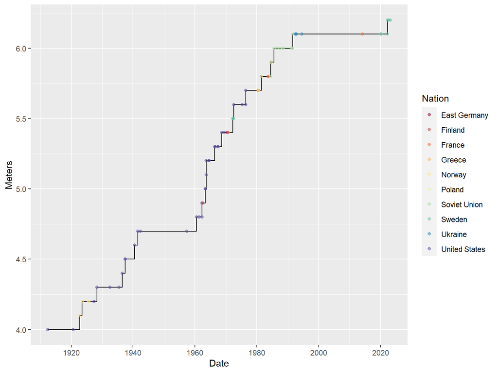

```r
PVMen %>%
  ggplot(aes(x = Date, y = Meters)) +
  geom_step() +
  geom_point(alpha = 0.5, aes(color = Nation))+
  scale_color_brewer(palette = "Spectral")
```

# Additional Resources

- https://www.datacamp.com/tutorial/regex-r-regular-expressions-guide
- https://github.com/rstudio/cheatsheets/blob/main/strings.pdf

# Assignments

- Reading Quiz Chapter 17 (due 11:59pm Sunday , July 30)
- Activity: Statistics of Gene Expression (due 9:59am Sunday , July 30)